# Visual Analytics - Deliverable 2

##Delivarable 2 Bivariate relationships : Categorical-Categorical

#1. We import the LSMS-ISA Nigeria Wave 3 Dataset from my personal repository

```r
library(rio)
rm(list = ls())
nigeria_w3<-read.csv('https://github.com/Sebastian-Wood-Visual-Analytics/deliverable1/raw/main/NGA_W3_EPAR.csv')
View(nigeria_w3)
```

#2. #Select some of the variables and create a new Dataset

```r
library(tidyverse)
nigeria_w3 <- select(nigeria_w3, hhid, zone, rural, daily_percap_cons, months_food_insec)
```

```r
#Preparing Contigency Tables
zones_monthsfinsecure=table(nigeria_w3$zone,nigeria_w3$months_food_insec,
                            exclude = '')
zones_monthsfinsecure
```

```
##
##                   0   1   2   3   4   5   6 <NA>
##   north central 694  33  35   8   6   4   1   19
##   north east    536  57  48   6   0   0   3  150
##   north west    771  34  66   1   4   5   5   14
##   south east    500  72  71  39  19  39  29   31
##   south south   619  21  82  13  16  12   4   33
##   south west    628  32  80  14  14  14   5  113
```

When a table tries to hypothesize a relationship, you should have the independent variable in the columns (food insecurity), and the dependent one (zones) in the rows. Interpretation is difficult when you have counts so it is better to have percents. Percents should be computed by column to see how the levels of the dependent variable varies by each level of the independent one (reading along rows):

```r
# computing column percent from contingency table
library(magrittr) # for %>%
(zones_monthsfinsecure.mgCol=prop.table(zones_monthsfinsecure,
                            margin = 2) #2 means by column
                             %>%round(.,3))
```

```
##
##                     0     1     2     3     4     5     6  <NA>
##   north central 0.185 0.133 0.092 0.099 0.102 0.054 0.021 0.053
##   north east    0.143 0.229 0.126 0.074 0.000 0.000 0.064 0.417
##   north west    0.206 0.137 0.173 0.012 0.068 0.068 0.106 0.039
##   south east    0.133 0.289 0.186 0.481 0.322 0.527 0.617 0.086
##   south south   0.165 0.084 0.215 0.160 0.271 0.162 0.085 0.092
##   south west    0.168 0.129 0.209 0.173 0.237 0.189 0.106 0.314
```

As before, we need to turn this table into a data frame:

```r
#making a data frame from contingency table
(zones_monthsfinsecureDF=as.data.frame(zones_monthsfinsecure))
```

| Var1 | Var2 | Freq |
| --- | --- | --- |
| north central | 0 | 694 |
| north east | 0 | 536 |
| north west | 0 | 771 |
| south east | 0 | 500 |
| south south | 0 | 619 |
| south west | 0 | 628 |
| north central | 1 | 33 |
| north east | 1 | 57 |
| north west | 1 | 34 |
| south east | 1 | 72 |

[output cut: 38 more lines]

```r
#We also have the table with marginal percents by column:

as.data.frame(zones_monthsfinsecure.mgCol)
```

| Var1 | Var2 | Freq |
| --- | --- | --- |
| north central | 0 | 0.185 |
| north east | 0 | 0.143 |
| north west | 0 | 0.206 |
| south east | 0 | 0.133 |
| south south | 0 | 0.165 |
| south west | 0 | 0.168 |
| north central | 1 | 0.133 |
| north east | 1 | 0.229 |
| north west | 1 | 0.137 |
| south east | 1 | 0.289 |

[output cut: 38 more lines]

```r
#We should simply add the last column to the data frame of counts.

zones_monthsfinsecureDF$share=as.data.frame(zones_monthsfinsecure.mgCol)[,3]
zones_monthsfinsecureDF
```

| Var1 | Var2 | Freq | share |
| --- | --- | --- | --- |
| north central | 0 | 694 | 0.185 |
| north east | 0 | 536 | 0.143 |
| north west | 0 | 771 | 0.206 |
| south east | 0 | 500 | 0.133 |
| south south | 0 | 619 | 0.165 |
| south west | 0 | 628 | 0.168 |
| north central | 1 | 33 | 0.133 |
| north east | 1 | 57 | 0.229 |
| north west | 1 | 34 | 0.137 |
| south east | 1 | 72 | 0.289 |

[output cut: 38 more lines]

```r
#We can change the names of the previous data frame:

names(zones_monthsfinsecureDF)[1:3]=c("zones","m_foodins","counts")

#then
zones_monthsfinsecureDF
```

| zones | m_foodins | counts | share |
| --- | --- | --- | --- |
| north central | 0 | 694 | 0.185 |
| north east | 0 | 536 | 0.143 |
| north west | 0 | 771 | 0.206 |
| south east | 0 | 500 | 0.133 |
| south south | 0 | 619 | 0.165 |
| south west | 0 | 628 | 0.168 |
| north central | 1 | 33 | 0.133 |
| north east | 1 | 57 | 0.229 |
| north west | 1 | 34 | 0.137 |
| south east | 1 | 72 | 0.289 |

[output cut: 38 more lines]

We will use ggplot to represent the contingency table:

```r
library(ggplot2)
base1=ggplot(data=zones_monthsfinsecureDF,
             aes(x=m_foodins,
                 y=share,
                 fill=zones)) # fill brings a legend
```

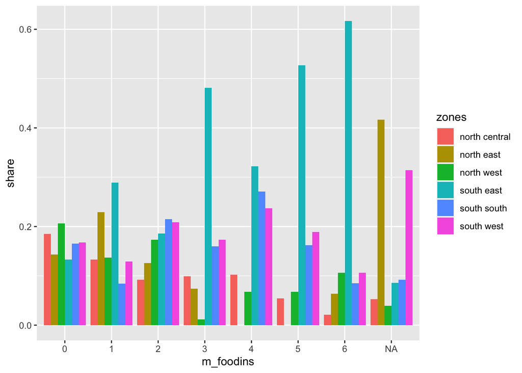

```r
#Then, you play with some positions for the bar. First, the dodge style:

barDodge= base1 +  geom_bar(stat="identity",
                            position ='dodge')
barDodge
```

Te second is the stack style:

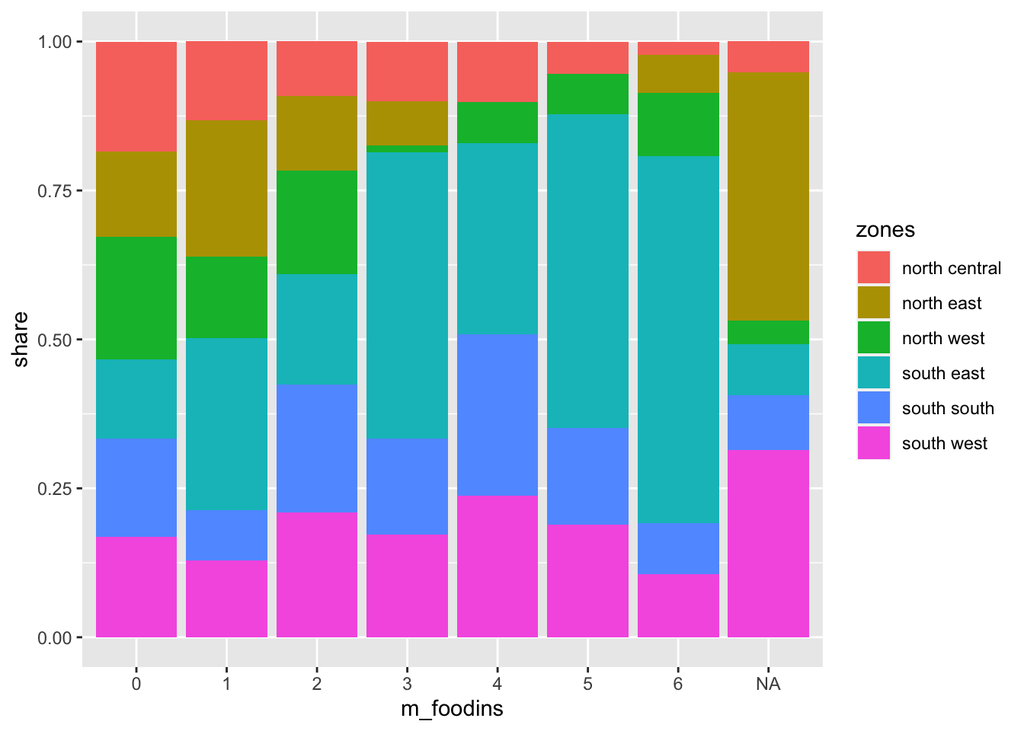

```r
barStacked = base1 + geom_bar(stat = "identity",
                              position = 'stack')#default
barStacked
```

The stacked version will help more than the dodged one as it reveals better the values in the contingency table:

```r
zones_monthsfinsecure.mgCol
```

```
##
##                     0     1     2     3     4     5     6  <NA>
##   north central 0.185 0.133 0.092 0.099 0.102 0.054 0.021 0.053
##   north east    0.143 0.229 0.126 0.074 0.000 0.000 0.064 0.417
##   north west    0.206 0.137 0.173 0.012 0.068 0.068 0.106 0.039
##   south east    0.133 0.289 0.186 0.481 0.322 0.527 0.617 0.086
##   south south   0.165 0.084 0.215 0.160 0.271 0.162 0.085 0.092
##   south west    0.168 0.129 0.209 0.173 0.237 0.189 0.106 0.314
```

So, we continue with adding some elements to this one:

```r
library(scales)
```

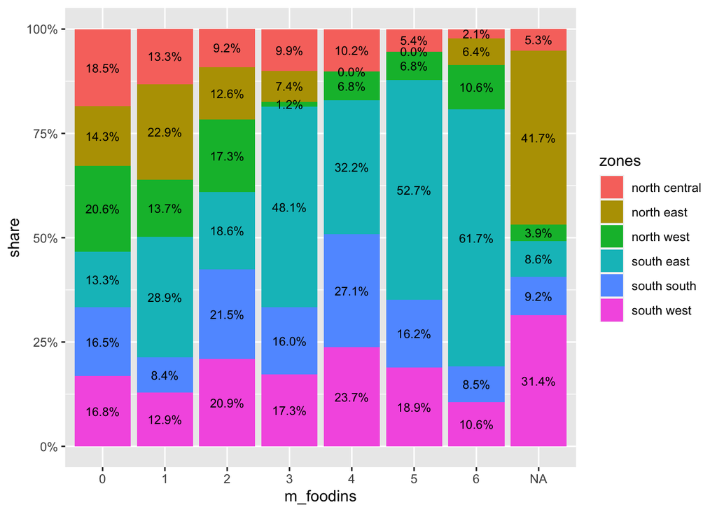

```r
#annotating
barStackedAnn= barStacked + geom_text(size = 3,# check below:
                             position = position_stack(vjust = 0.5),# center
                             aes(label=percent(share,accuracy = 0.1)))# percent format

barStackedAnn = barStackedAnn + scale_y_continuous(labels = percent)

barStackedAnn
```

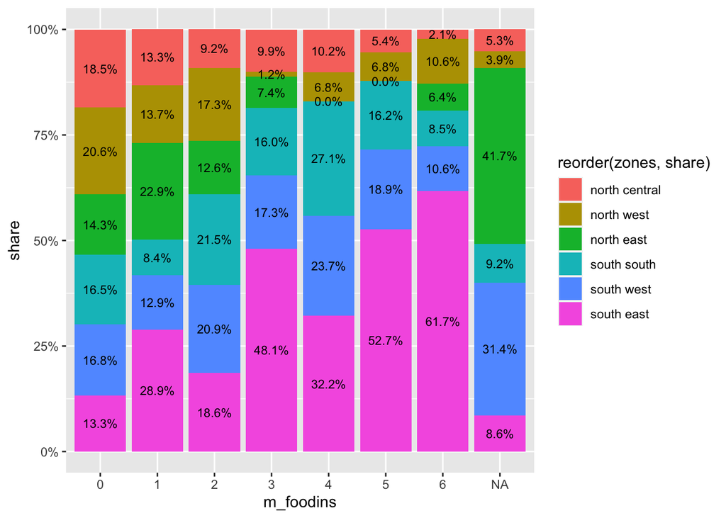

```r
base1=ggplot(data=zones_monthsfinsecureDF,
             aes(x=m_foodins, y=share,
                 fill=reorder(zones,share))) ## reordering

barStacked = base1 + geom_bar(stat = "identity",
                              position = 'stack')
barStacked= barStacked + geom_text(size = 3,
                             position = position_stack(vjust = 0.5),
                             aes(label=percent(share,accuracy = 0.1)))

barStacked = barStacked + scale_y_continuous(labels = percent)

barStacked
```

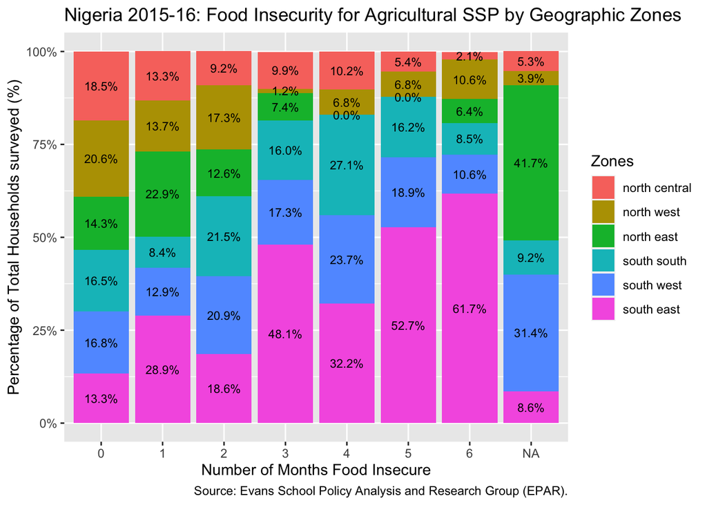

```r
#Add titles:
titleText='Nigeria 2015-16: Food Insecurity for Agricultural SSP by Geographic Zones'
sourceText='Source: Evans School Policy Analysis and Research Group (EPAR).'
x_axis='Number of Months Food Insecure'
y_axis='Percentage of Total Households surveyed (%)'
check="Zones"
barStacked = barStacked + labs(title=titleText,
                     x =x_axis,
                     y =y_axis,
                     caption = sourceText,
                     fill =check)
barStacked
```

#Upon Comments of Professor Magallanes I will create Facets

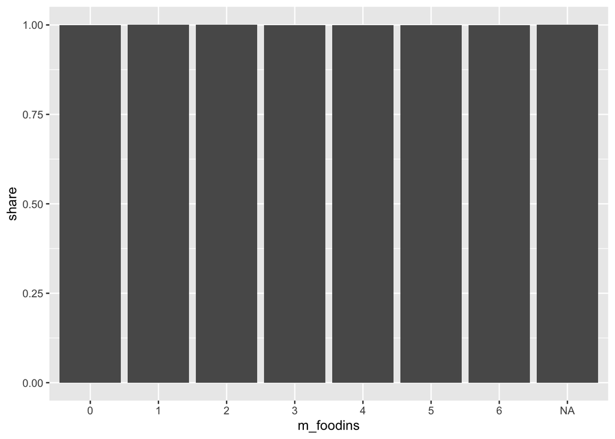

```r
#A first option you be to use a barplot with facets with bars dodged. Let’a make the first attempt.

# base with only X and Y in 'aes()'
baseBar = ggplot(zones_monthsfinsecureDF, aes(x = m_foodins, y = share ) )

#the bars
barPlot  = baseBar + geom_bar( stat = "identity" )

barPlot
```

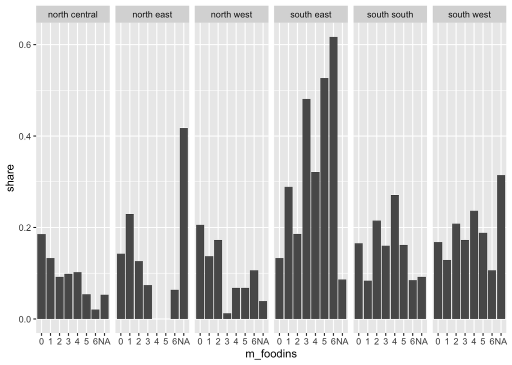

```r
#Now see the facets:

# bar per day time with 'facet'
barsFt = barPlot + facet_grid(~ zones)

barsFt
```

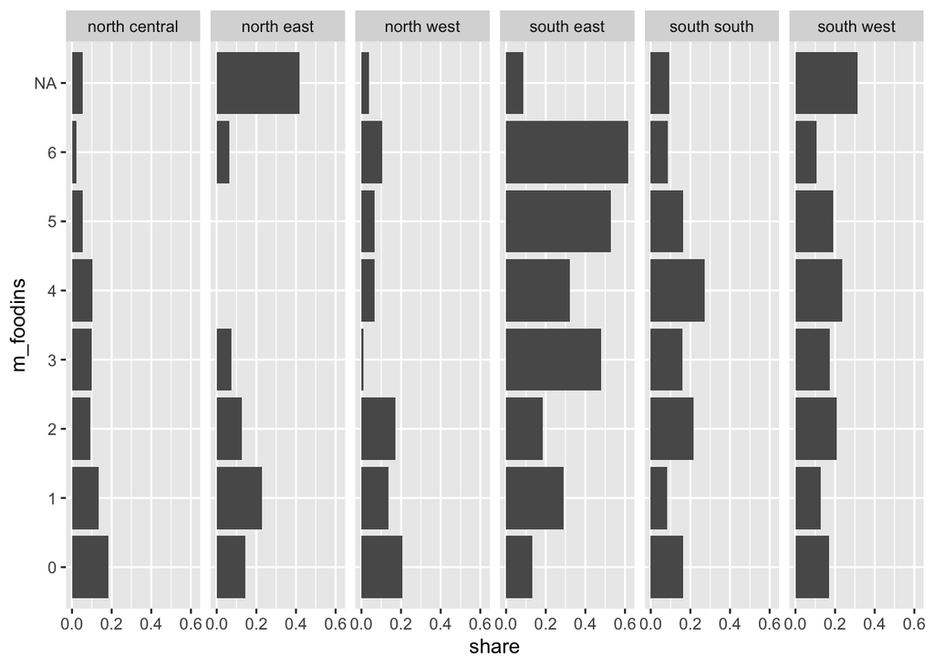

```r
#This does not look like the crosstable yet; let’s solve that:

barsFt + coord_flip()
```

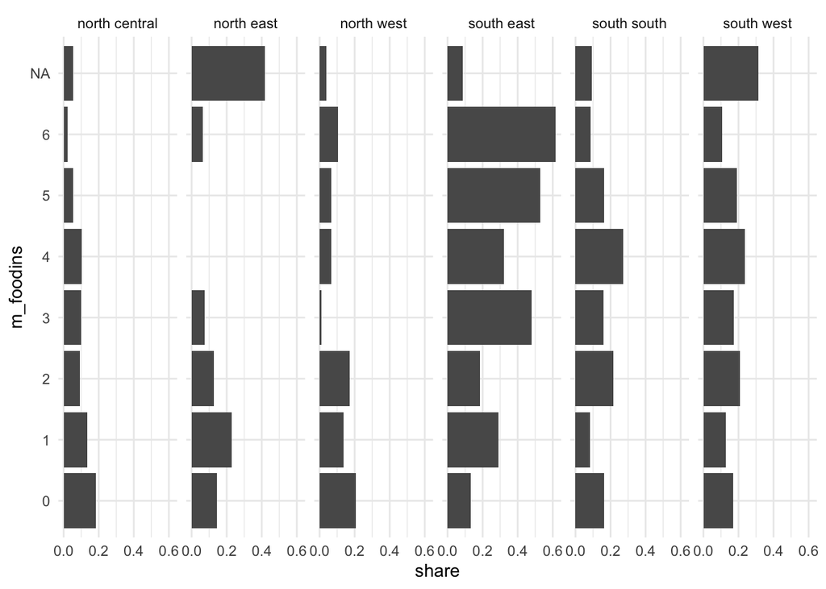

```r
# new base
baseRE  = ggplot(zones_monthsfinsecureDF,
                 aes(x = m_foodins, #here
                     y = share ) ) + theme_minimal()

barPlotRE = baseRE + geom_bar( stat = "identity" )
barFtRE = barPlotRE + facet_grid( ~ zones)
barFtRE= barFtRE + coord_flip()


barFtRE
```

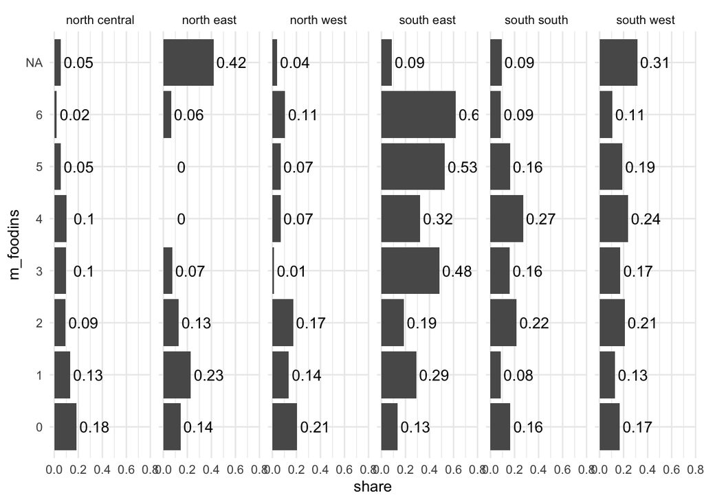

```r
#Would you annotate the bars:

barREann= barFtRE+ geom_text(aes(label=round(share,2)),
                             nudge_y = 0.15)
barREann
```

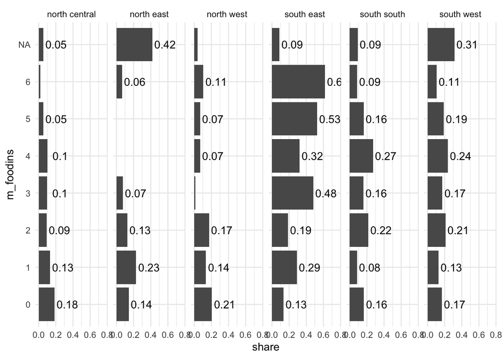

```r
#Let’s annotate conditionally instead:

barCond=barFtRE + geom_text(aes(label=ifelse(share>0.05,# condition to annotate
                                      round(share,2),"")),
                     nudge_y = 0.15)
barCond
```

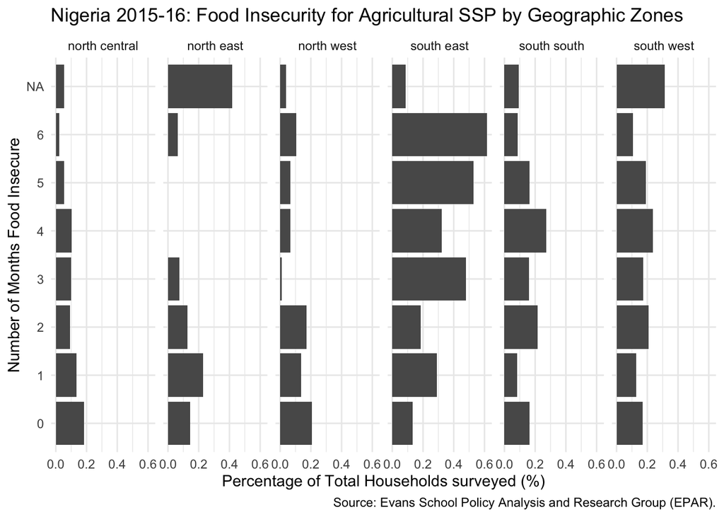

```r
#Add titles:
titleText='Nigeria 2015-16: Food Insecurity for Agricultural SSP by Geographic Zones'
sourceText='Source: Evans School Policy Analysis and Research Group (EPAR).'
x_axis='Number of Months Food Insecure'
y_axis='Percentage of Total Households surveyed (%)'
check="Zones"
barFtRE = barFtRE + labs(title=titleText,
                     x =x_axis,
                     y =y_axis,
                     caption = sourceText,
                     fill =check)
barFtRE
```

- Title/subtitle positions:

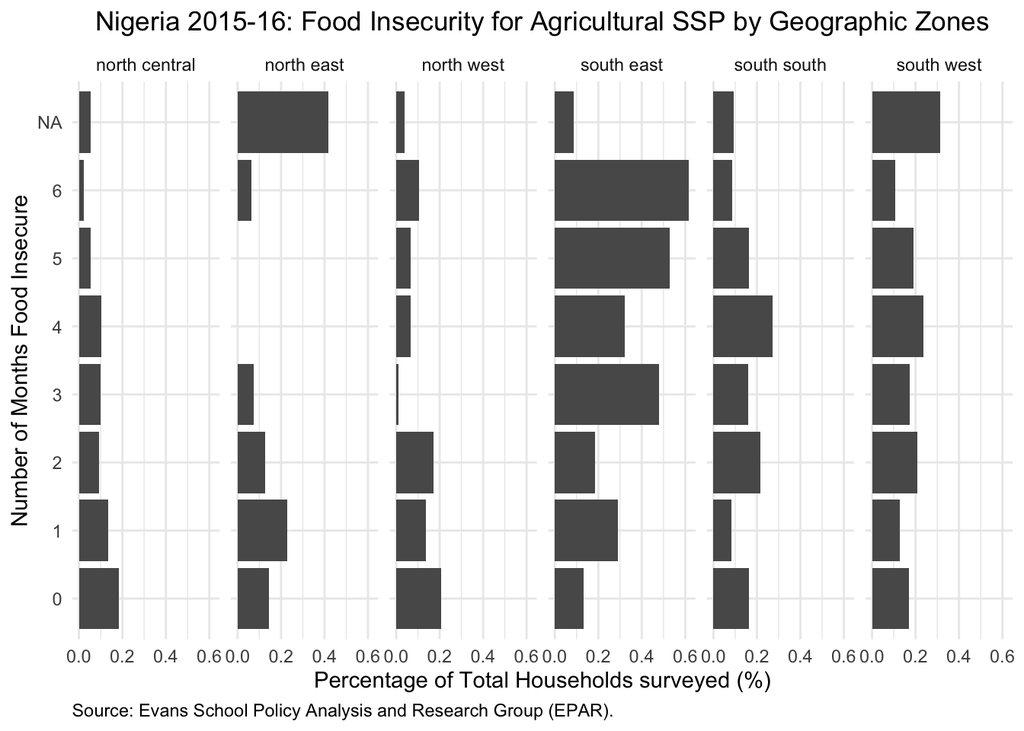

```r
#positions: 0 left / 1 right / 0.5 center
barFtRE = barFtRE + theme(plot.caption = element_text(hjust = 0),
                      plot.title = element_text(hjust = 0.5))
barFtRE
```

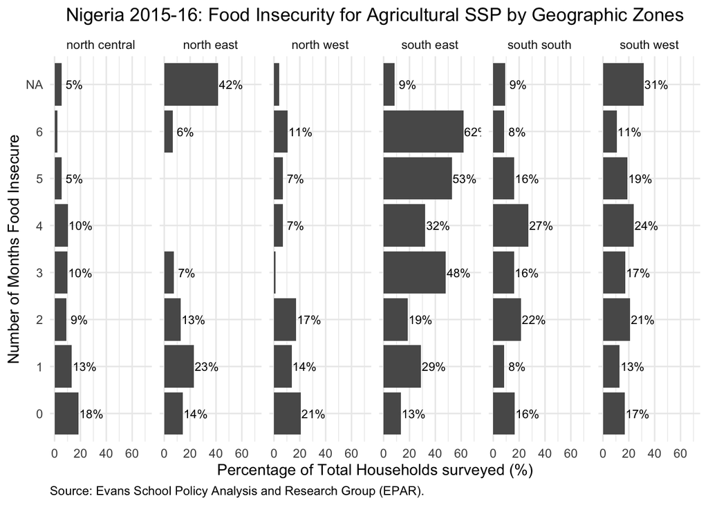

```r
#What about percents instead:

barFtRE + geom_text(aes(label=ifelse(share>0.05,
                                      percent(share,accuracy = 1),# %
                                     "")),
                     nudge_y = 0.1,size=3) +
           scale_y_continuous(labels = percent_format(accuracy = 1,suffix="")) #%
```